# LicitAI — Relatório Sprint 1

# Sprint 1 Análise e Especificação

Período: 11 de maio a 18 de maio de 2026 Total de pontos: 21 Todas as tarefas foram concluídas

## Planning Poker

| Tarefa | Alan | Luís Henrique | Pontuação final |
| --- | --- | --- | --- |
| LIC-3 Elaborar documento de descrição do sistema | 2 | 3 | 2 |
| LIC-4 Especificações dos requisitos com histórias de usuário | 3 | 3 | 3 |
| LIC-9 Criar repositório Git | 1 | 1 | 1 |
| LIC-5 Diagrama de casos de uso | 3 | 2 | 2 |
| LIC-8 Diagrama de arquitetura da solução | 2 | 2 | 2 |
| LIC-7 Diagrama Entidade-Relacionamento | 3 | 3 | 3 |
| LIC-6 Protótipo de média fidelidade | 5 | 3 | 3 |
| LIC-10 Docker Compose com PostgreSQL e pgvector | 3 | 5 | 3 |
| LIC-11 Script SQL de criação do banco | 2 | 2 | 2 |

## Kanban

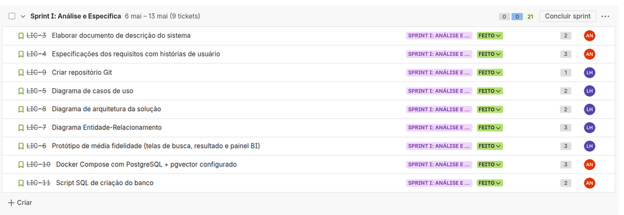

Quadro Kanban da Sprint I

## Burndown

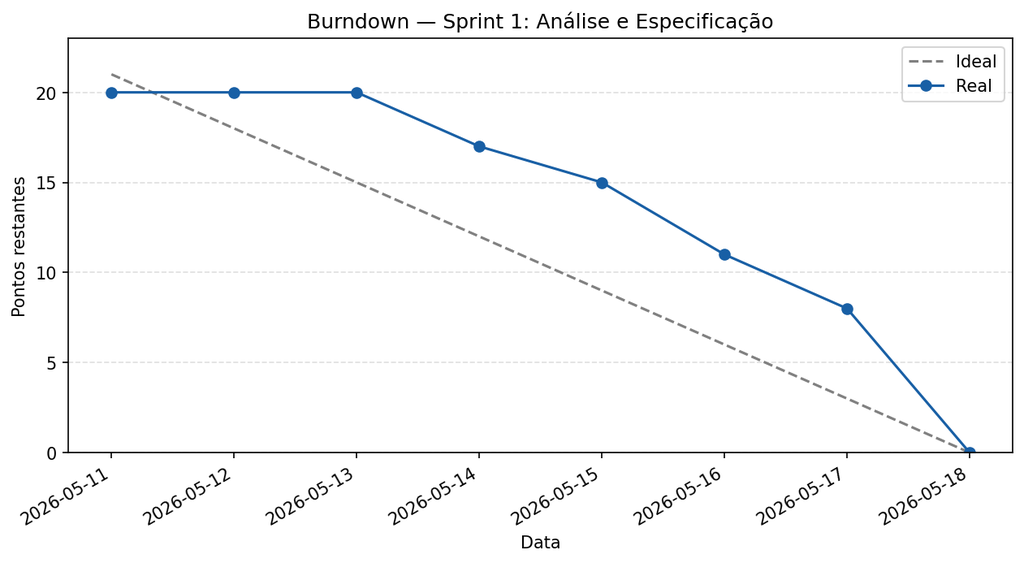

Burndown Sprint 1

# Descrição do Sistema — LicitAI

## Descrição geral

O LicitAI é uma plataforma de consulta e análise de licitações públicas brasileiras. O sistema coleta periodicamente dados do Portal Nacional de Contratações Públicas (PNCP), os armazena em base estruturada e os disponibiliza para consulta por meio de mecanismos de busca textual e de busca por similaridade semântica. A plataforma atende dois perfis de usuário: o usuário público, que realiza consultas e análises sem necessidade de autenticação, e o administrador, que opera e monitora o sistema.

O sistema permite que qualquer pessoa pesquise licitações utilizando tanto termos objetivos quanto descrições em linguagem natural. Os resultados podem ser refinados por critérios como unidade federativa, modalidade de contratação, faixa de valor e período de publicação. Cada licitação pode ser visualizada em detalhe, com informações sobre o órgão responsável, a unidade contratante, os itens do processo e os valores estimados. Um painel analítico apresenta indicadores agregados sobre o conjunto de licitações armazenadas.

Do lado operacional, o administrador define os parâmetros das coletas, acompanha o status de cada execução e pode exportar os dados para ferramentas externas de análise.

## Requisitos Funcionais

**RF01** O sistema deve realizar busca de licitações por termos textuais sobre o objeto da compra, retornando resultados ordenados por relevância

**RF02** O sistema deve realizar busca de licitações por linguagem natural, interpretando a consulta do usuário e recuperando resultados por similaridade semântica

**RF03** O sistema deve permitir que o usuário refine os resultados de qualquer modalidade de busca aplicando filtros por unidade federativa, modalidade de contratação, faixa de valor, situação e período de publicação

**RF04** O sistema deve exibir, em tela dedicada, todas as informações de uma licitação selecionada, incluindo dados do órgão contratante, itens do processo com quantidades e valores, datas relevantes e situação atual

**RF05** O sistema deve disponibilizar um painel com indicadores agregados sobre as licitações armazenadas, incluindo distribuição por modalidade, órgão e unidade federativa, e evolução temporal dos valores

**RF06** O sistema deve coletar licitações da API do PNCP a partir de parâmetros de data, modalidade e UF configurados pelo administrador, registrando cada execução com status e total de registros processados

**RF07** O sistema deve permitir que o administrador configure e agende coletas recorrentes sem necessidade de intervenção manual a cada execução

**RF08** O sistema deve disponibilizar ao administrador o histórico de execuções de coleta, com status, parâmetros utilizados e possibilidade de reprocessamento em caso de falha

**RF09** O sistema deve permitir que o administrador exporte os dados de licitações em formato CSV para uso em ferramentas externas de análise

## Rastreabilidade

| Requisito | Motivado por | Compõe |
| --- | --- | --- |
| RF01 | HU01 | UC01 |
| RF02 | HU02 | UC02 |
| RF03 | HU03 | UC01 UC02 UC03 |
| RF04 | HU04 | UC04 |
| RF05 | HU05 | UC05 |
| RF06 | HU06 | UC06 UC08 |
| RF07 | HU07 | UC07 |
| RF08 | HU08 | UC08 |
| RF09 | HU09 | UC09 |

# Histórias de Usuário — LicitAI

## Atores

**Usuário público** é o pesquisador, jornalista, fornecedor ou cidadão que consulta licitações sem autenticação

**Administrador** é o responsável pela operação da plataforma, pela configuração das coletas e pelo monitoramento do sistema

## Histórias do Usuário Público

### HU01 Busca por palavra-chave

Como usuário público quero pesquisar licitações digitando termos do objeto da compra para encontrar rapidamente editais relacionados ao meu interesse sem precisar navegar por portais governamentais

Requisito originado: RF01

### HU02 Busca por linguagem natural

Como usuário público quero descrever o que estou procurando com minhas próprias palavras e obter resultados relevantes mesmo que minha frase não corresponda exatamente ao texto do edital para que eu não precise conhecer o vocabulário técnico das licitações

Requisito originado: RF02

### HU03 Filtro por critérios objetivos

Como usuário público quero filtrar os resultados por estado, modalidade, faixa de valor, situação e período de publicação para restringir a busca ao contexto que me interessa e reduzir o volume de resultados irrelevantes

Requisito originado: RF03

### HU04 Detalhamento da licitação

Como usuário público quero ver todas as informações de uma licitação específica em uma única tela para avaliar se ela é relevante sem precisar acessar o PNCP diretamente

Requisito originado: RF04

### HU05 Visão analítica agregada

Como usuário público quero ver painéis com indicadores sobre volume de licitações, distribuição por modalidade, órgão ou região e evolução temporal dos valores para entender o comportamento das compras públicas em determinado contexto

Requisito originado: RF05

## Histórias do Administrador

### HU06 Coleta de dados do PNCP

Como administrador quero acionar a coleta de licitações na API do PNCP informando um intervalo de datas, modalidade e UF para manter a base de dados atualizada com novos editais publicados

Requisito originado: RF06

### HU07 Configuração dos parâmetros de coleta

Como administrador quero definir com antecedência os parâmetros de uma coleta como período, modalidade, UF e frequência para automatizar a atualização da base sem precisar intervir manualmente a cada execução

Requisito originado: RF07

### HU08 Monitoramento do sistema

Como administrador quero acompanhar os logs das coletas e o status de cada execução para identificar falhas, reprocessar coletas com erro e garantir a integridade dos dados

Requisito originado: RF08

### HU09 Exportação para BI

Como administrador quero exportar os dados de licitações em formato CSV para alimentar dashboards no Power BI com dados tratados e atualizados

Requisito originado: RF09

### Diagrama de Casos de Uso

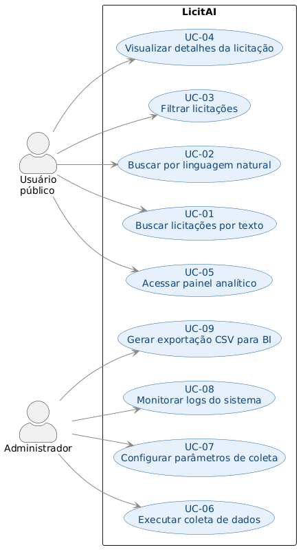

Diagrama de casos de uso

### Diagrama de Arquitetura da Solução

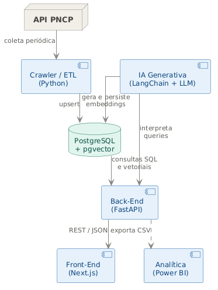

Diagrama de arquitetura

### Diagrama Entidade Relacionamento

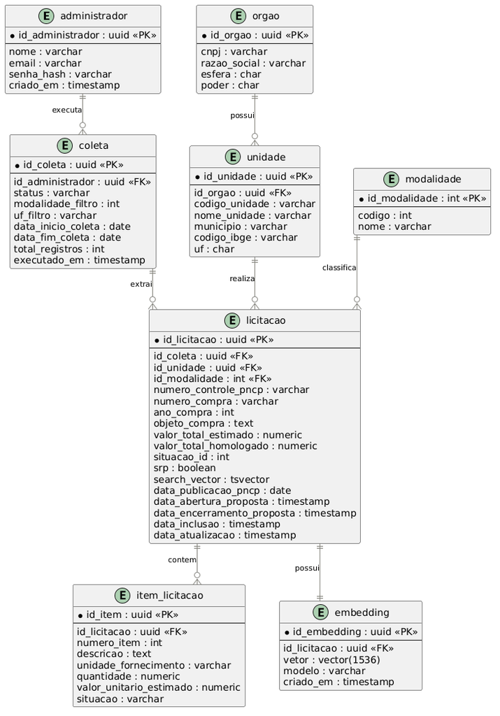

Diagrama Entidade-Relacionamento

### Demais artefatos

- [Protótipo de média fidelidade](https://lever-viola-39969495.figma.site/)
- [Repositório do projeto](https://github.com/LuisHBM/licitai)
- [Repositório de documentação](https://github.com/LuisHBM/tees-docs)
- Docker Compose com PostgreSQL e pgvector configurado
- Script SQL de criação do banco

## Retrospectiva

**O que funcionou bem**

A equipe chegou a uma definição interessante do tema do projeto e conseguiu alinhar o tema aos requisitos técnicos da disciplina, produzindo todos os artefatos previstos dentro do prazo

**O que não funcionou**

A sprint teve início desorganizado por causa de mudanças na composição da equipe. A produção ficou concentrada nos últimos dias desnecessariamente. A conciliação com a rotina fora da faculdade foi um fator muito limitante

**O que muda na próxima sprint**

Distribuir o trabalho de forma mais uniforme ao longo da semana, com alinhamentos diários entre os membros pelo WhatsApp para evitar que as entregas se acumulem próximo ao prazo